# A Quick Introduction to iNEXT.seq

2023-08-25

`iNEXT.seq` (iNterpolation and EXTrapolation for UniFrac distance) is an R package. In this document, we provide a quick introduction demonstrating how to run `iNEXT.seq`. Detailed information about `iNEXT.seq` functions is provided in the iNEXT.seq manual, also available in [CRAN](https://cran.r-project.org/package=iNEXT.seq). An online version of [iNEXT.seq-online](http://chao.stat.nthu.edu.tw/wordpress/software_download/iNEXT.seq-online/) is also available for users without an R background.

`iNEXT.seq` provides a new way to measure UniFrac distance, by applying dissimilarity measures based on Chiu’s et al.’s multiple assemblages decomposition (Chiu, Jost, and Chao (2014)). And we mainly consider three measures of Hill numbers of order q: species richness (`q = 0`), Shannon diversity (`q = 1`, the exponential of Shannon entropy) and Simpson diversity (`q = 2`, the inverse of Simpson concentration).

`iNEXT.seq` uses the observed sample of OTU count data (called the “reference sample”) to calculate UniFrac distance estimates and the associated confidence intervals for coverage-based rarefaction and extrapolation (R/E) curve.

`iNEXT.seq` computes dissimilarity as UniFrac distance estimates by doing monotonic transformation on phylogenetic beta diversity for rarefied and extrapolated samples, based on standardized levels of sample completeness (measured by sample coverage). This coverage-based sampling curve plots the diversity estimates with respect to sample coverage.

## SOFTWARE NEEDED TO RUN iNEXT.seq IN R

- Required: [R](https://cran.r-project.org/)
- Suggested: [RStudio IDE](https://www.rstudio.com/products/RStudio/#Desktop)

## HOW TO RUN iNEXT.seq:

The `iNEXT.seq` package is available from [CRAN](https://cran.r-project.org/package=iNEXT.seq) and can be downloaded with a standard R installation procedure or can be downloaded from Anne Chao’s [iNEXT.seq_github](https://github.com/yayunteng/iNEXT.seq) using the following commands. For a first-time installation, an additional visualization extension package (`ggplot2`) must be installed and loaded.

```r
## install iNEXT.seq package from CRAN
install.packages("iNEXT.seq")
## install the latest version from github
install.packages('devtools')
library(devtools)
install_github('yayunteng/iNEXT.seq')
## import packages
library(iNEXT.seq)
```

Here are two main functions we provide in this package :

- **iNEXTseq** : Computing dissimilarity estimates as UniFrac distances at specified sample coverage.
- **ggiNEXTseq** : Visualizing the output from the function `iNEXTseq`

## MAIN FUNCTION: iNEXTseq()

We first describe the main function `iNEXTseq()` with default arguments:

```r
iNEXTseq(data, q = c(0, 1, 2), base = "coverage", level = NULL, nboot = 10,
             conf = 0.95, PDtree = NULL, PDreftime = NULL)
```

[output not shown]

and `level = NULL`, then this function computes the gamma, alpha, beta diversity, and four dissimilarity-turnover indices estimates up to one (for q = 1, 2) or up to the coverage of double the reference sample size (for q = 0).

[output not shown]

This function returns an `"iNEXTseq"` object which can be further used to make plots using the function `ggiNEXTseq()` to be described below.

## DATA FORMAT/INFORMATION

Data should be provided as Individual-based abundance data.

Input data for each region with several assemblages/sites include samples species abundances in an empirical sample of n individuals (“reference sample”). When there are N assemblages in a region, input data consist of a list with an S by N abundance matrix; For M regions consisting N assemblages, input data should be M lists of S by N abundance matrix.

A data set (a microbiome sample take from tongue dorsum and buccal mucosa) is included in `iNEXT.seq` package for illustration. The data consist a species-by-assemblages matrix with two assemblages (tongue and cheek).For the data, the following commands display how to compute UniFrac distance estimate at specified sample coverage.

Run the following code to view `tongue_cheek` OTU count data: (Here we only show the first ten rows for the matrix)

```r
data("tongue_cheek")
tongue_cheek
```

```
#>              Cheek Tongue
#> OTU_97.10006     2      0
#> OTU_97.10025     1      0
#> OTU_97.1008      0      2
#> OTU_97.10090     2      0
#> OTU_97.101       1      1
#> OTU_97.10216     1      0
#> OTU_97.10217     3      0
#> OTU_97.10220     1      0
#> OTU_97.10238     0      1
#> OTU_97.1026      1      0
```

When `base = 'coverage'`, the `iNEXTseq()` function returns the `"iNEXTseq"` object including seven data frames for each regions:

- gamma
- alpha
- beta
- C (for UniFrac distance measured by Sorensen-type non-overlap )
- U (for UniFrac distance measured by Jaccard-type non-overlap )
- V (for UniFrac distance measured by Sorensen-type turnover )
- S (for UniFrac distance measured by Jaccard-type turnover )

When `base = 'size'`, the `iNEXTseq()` function returns the `"iNEXTseq"` object including two data frames for each regions:

- gamma
- alpha

## Rarefaction/Extrapolation Via Examples

Run the `iNEXTseq()` function with `tongue_cheek` data to compute UniFrac distance standardized by sample coverage. (Here we only show the first six rows for each output data frame)

```r
data("tongue_cheek")
data("tongue_cheek_tree")

out = iNEXTseq(data = tongue_cheek, q = c(0, 1, 2), nboot = 10,
                   PDtree = tongue_cheek_tree, PDreftime = NULL)
```

```
#> $gamma
#>        Dataset Order.q    SC    Size Estimate      Method  s.e.    LCL    UCL Diversity
#> 1 tongue_cheek       0 0.500 195.210   17.628 Rarefaction 0.181 17.273 17.983    meanPD
#> 2 tongue_cheek       0 0.525 238.659   18.504 Rarefaction 0.199 18.113 18.894    meanPD
#> 3 tongue_cheek       0 0.550 293.065   19.426 Rarefaction 0.222 18.992 19.861    meanPD
#> 4 tongue_cheek       0 0.575 362.025   20.400 Rarefaction 0.251 19.909 20.892    meanPD
#> 5 tongue_cheek       0 0.600 450.217   21.427 Rarefaction 0.288 20.863 21.991    meanPD
#> 6 tongue_cheek       0 0.625 563.559   22.510 Rarefaction 0.333 21.857 23.162    meanPD
#>
#> $alpha
#>        Dataset Order.q    SC    Size Estimate      Method  s.e.    LCL    UCL Diversity
#> 1 tongue_cheek       0 0.500 251.324   13.647 Rarefaction 0.148 13.356 13.937    meanPD
#> 2 tongue_cheek       0 0.525 305.770   14.364 Rarefaction 0.156 14.057 14.671    meanPD
#> 3 tongue_cheek       0 0.550 373.475   15.113 Rarefaction 0.167 14.786 15.439    meanPD
#> 4 tongue_cheek       0 0.575 458.672   15.903 Rarefaction 0.179 15.551 16.254    meanPD
#> 5 tongue_cheek       0 0.600 567.070   16.747 Rarefaction 0.195 16.364 17.129    meanPD
#> 6 tongue_cheek       0 0.625 706.332   17.660 Rarefaction 0.214 17.239 18.080    meanPD
#>
#> $beta
#>        Dataset Order.q    SC    Size Estimate      Method  s.e.   LCL   UCL Diversity
#> 1 tongue_cheek       0 0.500 251.324    1.292 Rarefaction 0.008 1.276 1.308    meanPD
#> 2 tongue_cheek       0 0.525 305.770    1.288 Rarefaction 0.009 1.271 1.306    meanPD
#> 3 tongue_cheek       0 0.550 373.475    1.285 Rarefaction 0.010 1.266 1.305    meanPD
#> 4 tongue_cheek       0 0.575 458.672    1.283 Rarefaction 0.011 1.262 1.304    meanPD
#> 5 tongue_cheek       0 0.600 567.070    1.279 Rarefaction 0.012 1.256 1.302    meanPD
#> 6 tongue_cheek       0 0.625 706.332    1.275 Rarefaction 0.013 1.250 1.300    meanPD
#>
#> $C
#>        Dataset Order.q    SC    Size Estimate      Method  s.e.   LCL   UCL Diversity
#> 1 tongue_cheek       0 0.500 251.324    0.292 Rarefaction 0.008 0.276 0.308    meanPD
#> 2 tongue_cheek       0 0.525 305.770    0.288 Rarefaction 0.009 0.271 0.306    meanPD
#> 3 tongue_cheek       0 0.550 373.475    0.285 Rarefaction 0.010 0.266 0.305    meanPD
#> 4 tongue_cheek       0 0.575 458.672    0.283 Rarefaction 0.011 0.262 0.304    meanPD
#> 5 tongue_cheek       0 0.600 567.070    0.279 Rarefaction 0.012 0.256 0.302    meanPD
#> 6 tongue_cheek       0 0.625 706.332    0.275 Rarefaction 0.013 0.250 0.300    meanPD
#>
#> $U
#>        Dataset Order.q    SC    Size Estimate      Method  s.e.   LCL   UCL Diversity
#> 1 tongue_cheek       0 0.500 251.324    0.452 Rarefaction 0.010 0.432 0.471    meanPD
#> 2 tongue_cheek       0 0.525 305.770    0.447 Rarefaction 0.011 0.426 0.469    meanPD
#> 3 tongue_cheek       0 0.550 373.475    0.444 Rarefaction 0.012 0.420 0.468    meanPD
#> 4 tongue_cheek       0 0.575 458.672    0.441 Rarefaction 0.014 0.414 0.467    meanPD
#> 5 tongue_cheek       0 0.600 567.070    0.437 Rarefaction 0.015 0.408 0.466    meanPD
#> 6 tongue_cheek       0 0.625 706.332    0.431 Rarefaction 0.016 0.399 0.463    meanPD
#>
#> $V
#>        Dataset Order.q    SC    Size Estimate      Method  s.e.   LCL   UCL Diversity
#> 1 tongue_cheek       0 0.500 251.324    0.292 Rarefaction 0.008 0.276 0.308    meanPD
#> 2 tongue_cheek       0 0.525 305.770    0.288 Rarefaction 0.009 0.271 0.306    meanPD
#> 3 tongue_cheek       0 0.550 373.475    0.285 Rarefaction 0.010 0.266 0.305    meanPD
#> 4 tongue_cheek       0 0.575 458.672    0.283 Rarefaction 0.011 0.262 0.304    meanPD
#> 5 tongue_cheek       0 0.600 567.070    0.279 Rarefaction 0.012 0.256 0.302    meanPD
#> 6 tongue_cheek       0 0.625 706.332    0.275 Rarefaction 0.013 0.250 0.300    meanPD
#>
#> $S
#>        Dataset Order.q    SC    Size Estimate      Method  s.e.   LCL   UCL Diversity
#> 1 tongue_cheek       0 0.500 251.324    0.452 Rarefaction 0.010 0.432 0.471    meanPD
#> 2 tongue_cheek       0 0.525 305.770    0.447 Rarefaction 0.011 0.426 0.469    meanPD
#> 3 tongue_cheek       0 0.550 373.475    0.444 Rarefaction 0.012 0.420 0.468    meanPD
#> 4 tongue_cheek       0 0.575 458.672    0.441 Rarefaction 0.014 0.414 0.467    meanPD
#> 5 tongue_cheek       0 0.600 567.070    0.437 Rarefaction 0.015 0.408 0.466    meanPD
#> 6 tongue_cheek       0 0.625 706.332    0.431 Rarefaction 0.016 0.399 0.463    meanPD
```

## GRAPHIC DISPLAYS: FUNCTION ggiNEXTseq()

The function `ggiNEXTseq()`, which extends `ggplot2` to the `"iNEXTseq"` object with default arguments, is described as follows:

```r
ggiNEXTseq(output, type = "B", scale = "fixed", transp = 0.4)
```

| Argument | Description |
| --- | --- |
| `output` | the output of `iNEXTseq`. |
| `type` | selection of plot type : type = ‘B’ for plotting the gamma, alpha, and beta diversity; type = ‘D’ for plotting 4 dissimilarities. |
| `scale` | Are scales shared across all facets (the default, `“fixed”`), or do they vary across rows (`“free_x”`), columns (`“free_y”`), or both rows and columns (`“free”`)? |
| `transp` | a value between 0 and 1 controlling transparency. transp = 0 is completely transparent, default is `0.4`. |

The `ggiNEXTseq()` function is a wrapper around the `ggplot2` package to create a R/E curve using a single line of code. The resulting object is of class `"ggplot"`, so it can be manipulated using the `ggplot2` tools. Users can visualize the output of beta diversity or four dissimilarities by setting the parameter `type`:

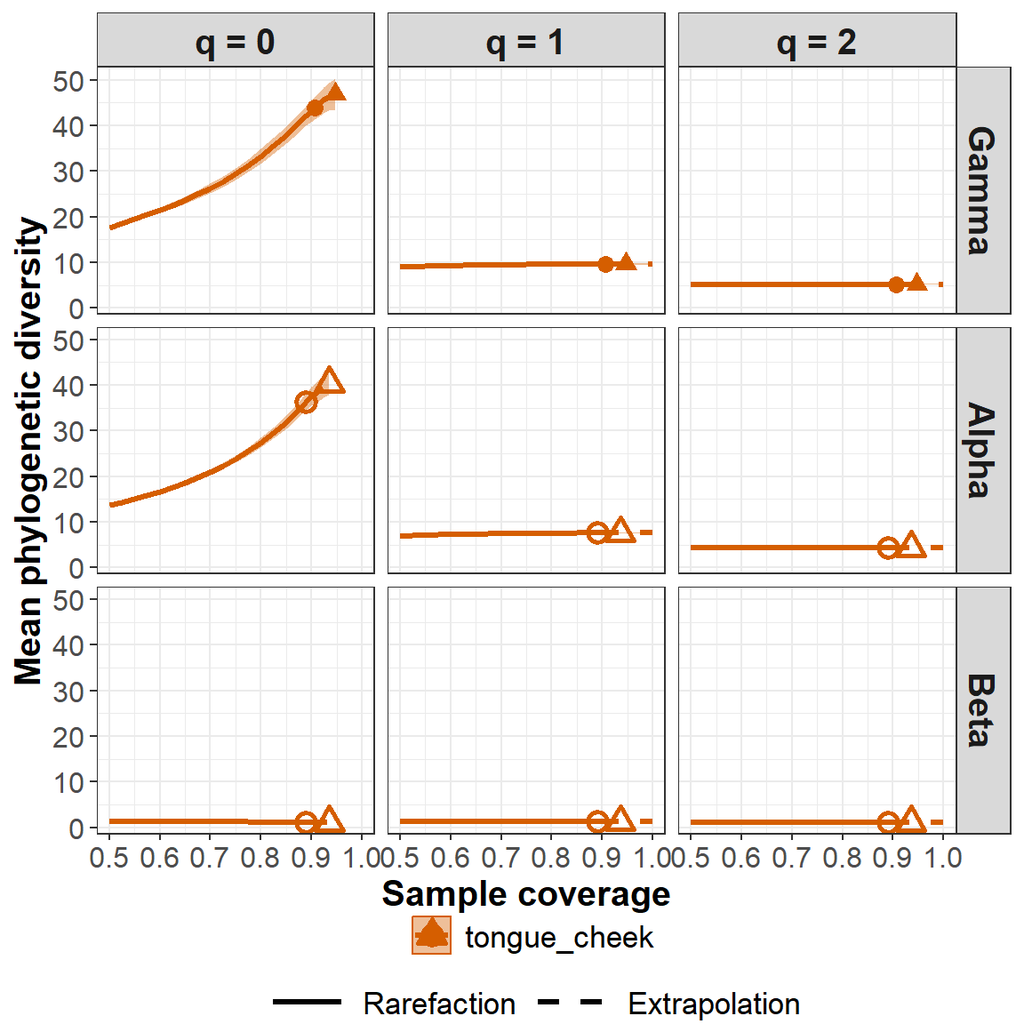

```r
out = iNEXTseq(data = tongue_cheek, q = c(0, 1, 2), nboot = 10,
                   PDtree = tongue_cheek_tree, PDreftime = NULL)
ggiNEXTseq(out, type = "B")
```

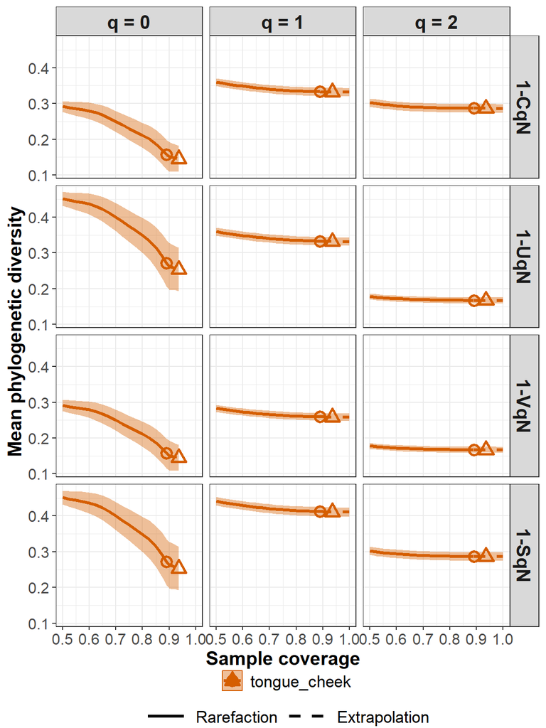

```r
ggiNEXTseq(out, type = "D")
```

The following commands return the size-based R/E sampling curves for gamma and alpha diversity:

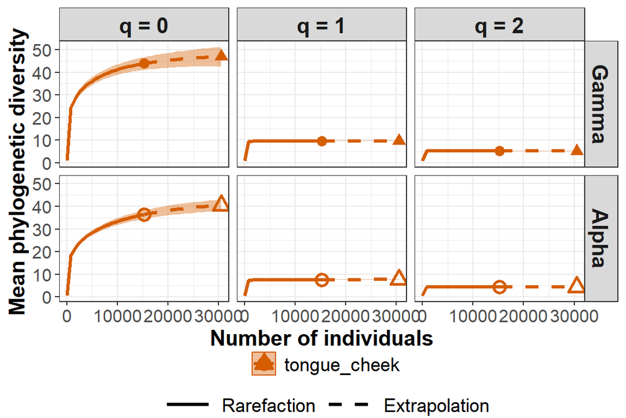

```r
out = iNEXTseq(data = tongue_cheek, q = c(0, 1, 2), base = "size",
                   nboot = 10, PDtree = tongue_cheek_tree, PDreftime = NULL)
ggiNEXTseq(out)
```

## References

- Chiu, C.-H., Jost, L. and Chao*, A. (2014). Phylogenetic beta diversity, similarity, and differentiation measures based on Hill numbers. Ecological Monographs 84, 21-44.